# Benchmarking Study

- Show All Code
- Hide All Code
- View Source

Replication Report

Author

Affiliation

*blinded for review*

*blinded for review*

# 1 Introduction

To ensure that our experimental pitch decks appeared realistic and ecologically valid in terms of design and fluency, we benchmarked their visual fluency against 3,510 real pitch decks submitted to a European venture capital firm specializing in seed-stage investments. Importantly, since these real pitch decks include both successful and unsuccessful funding attempts, this approach mitigates the survivorship bias inherent in publicly available pitch decks, which are typically limited to successful cases and may overrepresent higher visual fluency.

In what follows, we will shortly describe the results of the benchmarking study. As this report is dynamically created with R and Quarto, we also report all code. However, for readability, code is hidden by default and only the relevant results are shown. You can expand individual code blocks by clicking on them, or use the `</> Code` button (top-right) to reveal all code or view the complete source.

```r
# setup
library(ggplot2)
library(kableExtra)
library(rlang) # enables `%||%` (default value for NULL)

# further packages that are loaded on demand are:
# - here
# - readr
# - hrbrthemes
# - scales
# - stringr

# set option to disable showing the column types when loading data with `readr`
options("readr.show_col_types" = FALSE)

# -----------------------------------------------------------------------------
# custom colors and themes
# -----------------------------------------------------------------------------
#
# colors
theme_colors <- list(
  percentiles = "black",
  fill = "grey80",
  emphasis = "#297FB8",
  emphasis_text = "black",
  axis = "black",
  grid = "grey80"
)

# custom theme
custom_theme <- hrbrthemes::theme_ipsum_rc() +
  theme(
    panel.grid.major.y = element_line(color = theme_colors$grid),
    panel.grid.major.x = element_blank(),
    panel.grid.minor = element_blank(),
    axis.line = element_blank(),
    plot.title = element_text(hjust = 0, size = 18, family = "Roboto Condensed", face = "bold"),
    plot.subtitle = element_text(hjust = 0, size = 14, family = "Roboto Condensed", margin = margin(b = 25)),
    plot.caption = element_text(hjust = 0.5, family = "Roboto Condensed"),
    axis.title.x = element_text(size = 12, margin = margin(t = 10, b = 0), hjust = 0.5, color = theme_colors$axis),
    axis.text.x = element_text(angle = 0, hjust = 0.5, size = 10, color = theme_colors$axis),
    axis.text.y = element_text(size = 10, color = theme_colors$axis),
    axis.title.y = element_text(size = 12, margin = margin(l = -20, r = 10), hjust = 0.5, color = theme_colors$axis),
    plot.margin = margin(t = 40, r = 20, b = 40, l = 40, unit = "pt")
  )


# -----------------------------------------------------------------------------
# custom plot function
# -----------------------------------------------------------------------------
#
# function to create density plot with percentiles and benchmarks
create_density_plot <- function(

    data,               # data frame with data for all pitch decks
    metric,             # metric to plot
    benchmark_values,   # values for benchmarks
    benchmark_labels,   # labels for benchmarks
    title = NULL,       # title for the plot
    save_plot = FALSE   # save the plot as png

    ) {

  # calculate density and percentiles
  metric_density <- density(data[[metric]])
  metric_percentiles <- quantile(data[[metric]],
                                 probs = c(0.01, 0.05, 0.10, 0.25, 0.5,
                                           0.75, 0.9, 0.95, 0.99))

  # create percentile lines data
  perc_lines <- data.frame(
    x = metric_percentiles,
    y = approx(metric_density$x, metric_density$y, xout = metric_percentiles)$y,
    label = c("p1", "p5", "p10", "p25", "p50", "p75", "p90", "p95", "p99")
  )

  # create benchmark data
  benchmarks <- data.frame(
    values = benchmark_values,
    labels = benchmark_labels
  )

  # create plot
  plot <- ggplot(data, aes(!!sym(metric))) +
    geom_density(fill = theme_colors$fill, alpha = 0.65, color = "white", linewidth = .65) +
    geom_segment(data = perc_lines,
                aes(x = x, xend = x, y = 0, yend = y),
                color = theme_colors$percentiles, linetype = "dashed") +
    geom_text(data = perc_lines,
              aes(x = x, y = 0, label = label),
              vjust = 1.5, size = 3, color = theme_colors$percentiles, fontface = "italic", family = "Roboto Condensed") +
    geom_segment(data = benchmarks,
                aes(x = values, xend = values, y = 0, yend = max(metric_density$y)),
                color = theme_colors$emphasis, linewidth = 1) +
    geom_text(data = benchmarks,
              aes(x = values, y = max(metric_density$y), label = labels),
              vjust = -1, size = 4, color = theme_colors$emphasis_text, family = "Roboto Condensed") +
    scale_x_continuous(
      labels = scales::number_format(accuracy = 0.01),
      breaks = scales::pretty_breaks(n = 10)
    ) +
    custom_theme +
    labs(
      title = title %||% paste("Distribution of", stringr::str_to_lower(metric), "scores"),
      x = paste(stringr::str_to_title(metric), "score"),
      y = "Density",
      subtitle = paste(scales::comma(nrow(data)), "pitch decks"),
      caption = "Note: Dashed lines represent key percentiles. Solid lines represent the average scores of our pitch decks used in the experiments."
    )

  # save plot if requested
  if(save_plot){
    filename <- paste0("Benchmark_Plot_", stringr::str_to_title(metric), ".png")
    ggsave(filename, plot, width = 12, height = 8, dpi = 300)
  }

  return(plot)
}
```

# 2 Data

We provided the VC firm with a script that uses the *imagefluency* package (Mayer, [2024](https://imagefluency.com/)) to compute simplicity, symmetry, and contrast values for all pitch decks in their database. In the present replication report, we load the data we got back from the VC firm.

```r
data_dir <- 'replication_reports/data'

pitch_data <- readr::read_csv(here::here(data_dir, 'Pitchdeck_Benchmarks.csv'))
# no further processing needed
```

# 3 Plots

Figure 1 shows the distribution of visual fluency across the VC’s deck database. In particular, Figure 1 (a) shows the distribution of visual contrast, Figure 1 (b) shows the distribution of visual simplicity, and Figure 1 (c) shows the distribution of visual symmetry. In each distribution, we highlight the position of our experimental pitch decks’ scores to illustrate how they compare to the overall range. The density is based on the average of the individual slides of the pitch decks, and the scores for the low and high fluency pitch decks are the average per condition.

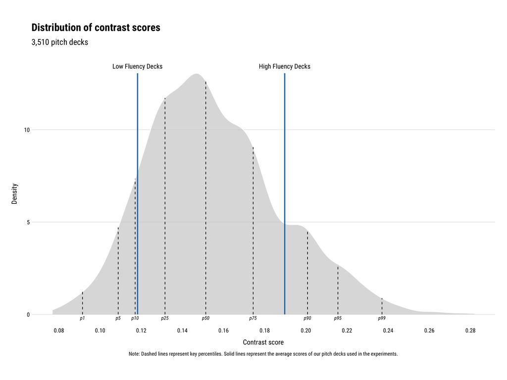

(a) Contrast scores

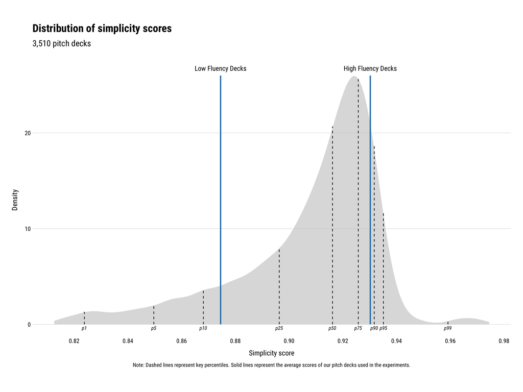

(b) Simplicity scores

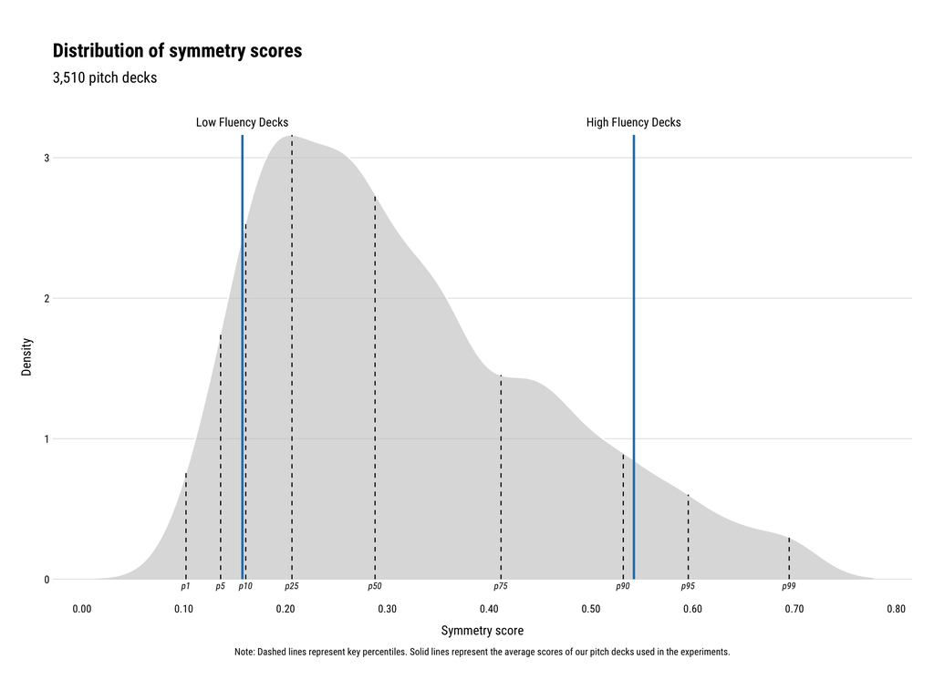

(c) Symmetry scores

Figure 1: Distribution of contrast, simplicity, and symmetry scores in real pitch decks from a European VC firm and comparison with the scores of the low and high fluency pitch decks from our field experiment.

```r
# NOTE: below custom plot function is defined at the beginning of this document

# contrast plot
create_density_plot(
  data = pitch_data,
  metric = "contrast",
  benchmark_values = c(0.118188, 0.189691),
  benchmark_labels = c("Low Fluency Decks", "High Fluency Decks")
)

# simplicity plot
create_density_plot(
  data = pitch_data,
  metric = "simplicity",
  benchmark_values = c(0.874492, 0.930208),
  benchmark_labels = c("Low Fluency Decks", "High Fluency Decks")
)

# symmetry plot
create_density_plot(
  data = pitch_data,
  metric = "symmetry",
  benchmark_values = c(0.157513, 0.542096),
  benchmark_labels = c("Low Fluency Decks", "High Fluency Decks")
)
```

Overall, Figure 1 highlights that our experimental low-fluency decks fall close to the 10th percentile of the distributions, while the high-fluency decks are near the 90th percentiles.